# Sunspots: NNS vs. KERAS

# Intro

We are comparing RMSE of eleven 10 year predictions (120 monthly observations) for the `sunspot.month` dataset in R using `KERAS LSTM` and `NNS.ARMA`.

## Long Short-Term Memory (LSTM) Models

LSTMs are quite useful in time series prediction tasks involving autocorrelation, the presence of correlation between the time series and lagged versions of itself, because of their ability to maintain state and recognize patterns over the length of the time series.

In normal (or `stateless`) mode, `KERAS` shuffles the samples, and the dependencies between the time series and the lagged version of itself are lost. However, when run in `stateful` mode, we can often get high accuracy results by leveraging the autocorrelations present in the time series.

`KERAS LSTM` description and example with accompanying code (lots of it!) available via the following link: https://www.business-science.io/timeseries-analysis/2018/04/18/keras-lstm-sunspots-time-series-prediction.html

## NNS.ARMA

`NNS` in its forecasting routine `NNS.ARMA` also maintains the dependencies between the time series and lagged values of itself, and then uses these dependencies in a regression (either linear or nonlinear).  
See here for a thorough description: https://www.researchgate.net/publication/327495856_Forecasting

### Install the Latest Version of `NNS (>= 11.6.3)`

```r
#library(devtools); install_github('OVVO-Financial/NNS', ref = "NNS-Beta-Version")
library(NNS)
library(Metrics)
library(xts)
library(zoo)
library(doParallel)
```

# Step 1: Create the Subsets of `sunspot.month`

We need to align dates to the `KERAS` example, so we create an `xts` object to manipulate the dates and verify they match.

```r
sunspots_xts <- as.xts(sunspot.month)

tmp <- tempfile()

write.zoo(sunspots_xts, sep = ",", file = tmp)

sun <- read.zoo(tmp, sep = ",", FUN = as.yearmon)

sun_xts <- as.xts(sun)

# Create the same end date for all slices
dates=c("/18081202", "/18290102", "/18490202", "/18690302", "/18890402",
        "/19090502","/19290602","/19490702","/19690802","/19890902","/20091002")

Slice=list()

for(i in 1:11){
  Slice[[paste0("Slice_",i)]] = sun_xts[dates[i]]
  print(tail(Slice[[i]],1))
}
```

```
##          [,1]
## Dec 1808 12.3
##          [,1]
## Jan 1829   43
##           [,1]
## Feb 1849 131.8
##          [,1]
## Mar 1869 52.7
##          [,1]
## Apr 1889  4.3
##          [,1]
## May 1909   36
##          [,1]
## Jun 1929 71.9
##           [,1]
## Jul 1949 125.8
##          [,1]
## Aug 1969   98
##           [,1]
## Sep 1989 176.7
##          [,1]
## Oct 2009  4.8
```

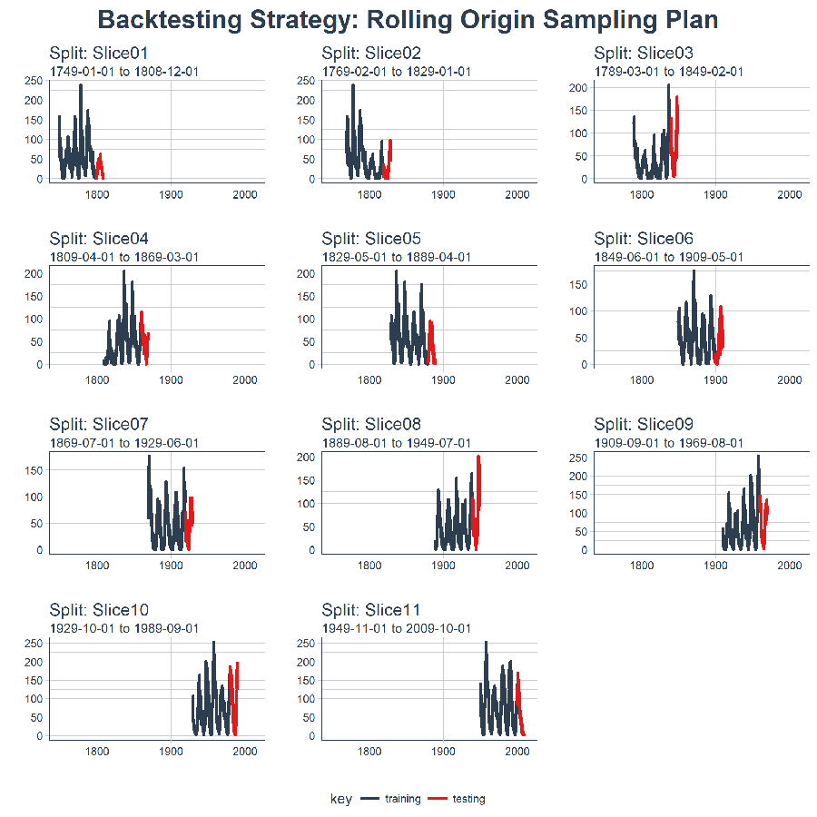

# Step 2: Determine the seasonality

Here’s the general procedure on a single `Slice`.

We use a modulo 12 `(%%12)` call on the generated seasonal periods from `NNS.seas` to find the nearest logical annual cycle data point.

*No test set leakage into the detected seasonal periods as we are eliminating the last 120 observations from the variable and store it in the new variable `training`.*

```r
training = Slice[[6]][1:(length(Slice[[6]])-120)]

periods = NNS.seas(training, modulo = 12)$periods
```

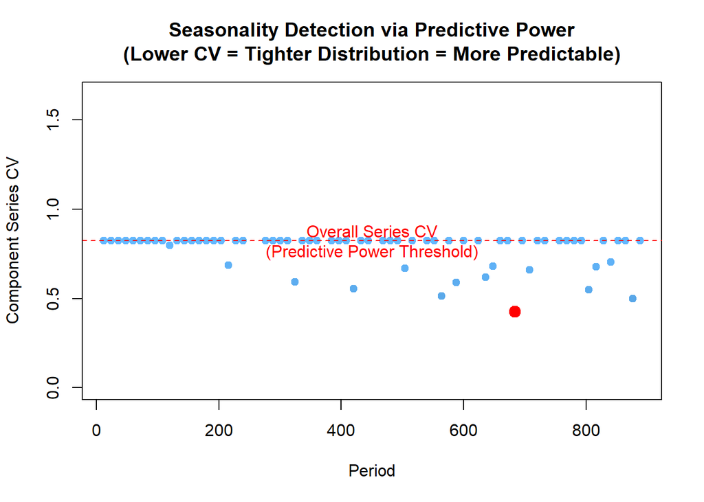

```r
head(periods)
```

```
## [1] 684 876 564 804 420 588
```

# Step 3: Determine the Optimal Parameters

The `NNS.ARMA.optim` routine checks various parameter combinations in order to best fit the training set according to any objective function specified. We store this under variable `b`. `NNS.ARMA.optim` returns the optimal seasonal periods, the objective function result, and which `NNS` regression method was used: linear, nonlinear, or a combination of both.

We also specify the objective function via `obj.fn = expression(Metrics::rmse(actual, predicted))` and the objective to minimize it. Any objective function can be used, calling the specific terms `actual` and `predicted` within the `expression(...)` call.

```r
start.time = Sys.time()
nns.predict = NNS.ARMA.optim(variable = training,
                             h = 120,
                             seasonal.factor = periods,
                             obj.fn = expression(Metrics::rmse(actual, predicted)),
                             objective = "min",
                             print.trace = TRUE)$results
```

[output not shown]

```r
Sys.time() - start.time
```

```
## Time difference of 40.21502 secs
```

# Step 4: Calculate `NNS` RMSE

The performance measure used is the root mean squared error (RMSE) against the last 120 observations of that particular `Slice`.

```r
Metrics::rmse(predicted = nns.predict, actual = tail(Slice[[6]], 120))
```

```
## [1] 24.93657
```

# Step 5: Compare `NNS` RMSE with `KERAS LSTM` RMSE

[figure not shown]

# Step 6: Let’s try all the slices…

We compare `KERAS` implementation of its rolling forecasts, to `NNS` forecasts per `Slice`. `KERAS` generates $\mu_{RMSE}=34.4$ and $\sigma_{RMSE} = 13.0$.

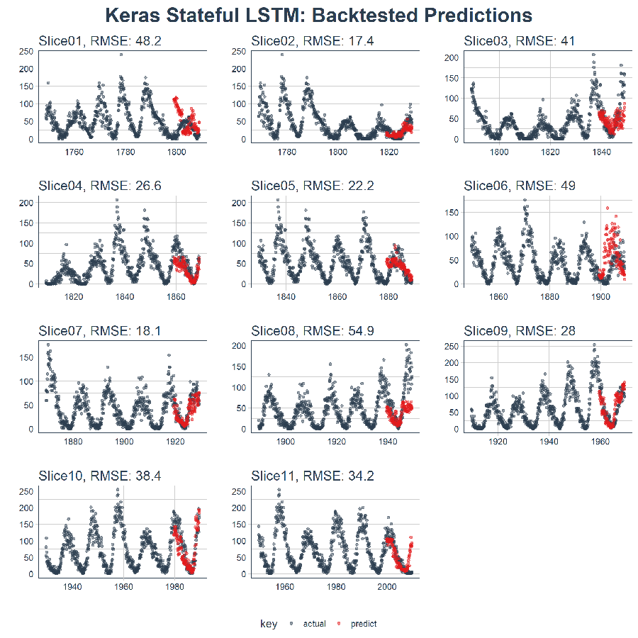

```r
start.time=Sys.time()
NNS.RMSE = list()

# Run in parallel

cl <- makeCluster(detectCores()-1)
registerDoParallel(cl)



NNS.RMSE <- foreach(i = 1:11,.packages=c("NNS", "Metrics") ) %dopar% {
  training = as.vector(Slice[[i]][1:(length(Slice[[i]])-120)])

  # Seasonality per slice
  periods = NNS.seas(training, modulo = 12, plot = FALSE)$periods

  # Determine optimal parameters
  nns.predictions = NNS.ARMA.optim(variable = training,
                                   h = 120,
                                   seasonal.factor = periods,
                                   obj.fn = expression(Metrics::rmse(actual, predicted)),
                                   objective = "min",
                                   ncores = 1,
                                   print.trace = FALSE)$results

  # RMSE call
  Metrics::rmse(predicted = nns.predictions, actual = tail(Slice[[i]], 120))
}

stopCluster(cl)
registerDoSEQ()
print(Sys.time()-start.time)
```

```
## Time difference of 4.545993 mins
```

# Results & Comments

## Per Slice results:

```r
"NNS.RMSE"=as.vector(unlist(NNS.RMSE))
"KERAS.RMSE"=c(48.2,17.4,41,26.6,22.2,49,18.1,54.9,28,38.4,34.2)

print(as.data.frame(cbind(NNS.RMSE, KERAS.RMSE, "NNS % Improvement"=1-NNS.RMSE/KERAS.RMSE),
              row.names = names(Slice)))
```

```
##          NNS.RMSE KERAS.RMSE NNS % Improvement
## Slice_1  23.20313       48.2        0.51860729
## Slice_2  26.36671       17.4       -0.51532841
## Slice_3  31.80686       41.0        0.22422288
## Slice_4  30.10533       26.6       -0.13177926
## Slice_5  34.32120       22.2       -0.54599999
## Slice_6  24.93657       49.0        0.49109032
## Slice_7  26.22320       18.1       -0.44879550
## Slice_8  67.10959       54.9       -0.22239690
## Slice_9  26.13460       28.0        0.06662145
## Slice_10 29.38657       38.4        0.23472487
## Slice_11 33.57341       34.2        0.01832141
```

## Aggregate results:

```r
"Mean NNS.RMSE"=mean(NNS.RMSE)

"SD NNS.RMSE"=sd(NNS.RMSE)

rbind(`Mean NNS.RMSE`,
      `Mean KERAS.RMSE`=mean(KERAS.RMSE),
      `SD NNS.RMSE`,
      `SD KERAS.RMSE`=sd(KERAS.RMSE))
```

```
##                     [,1]
## Mean NNS.RMSE   32.10611
## Mean KERAS.RMSE 34.36364
## SD NNS.RMSE     12.15593
## SD KERAS.RMSE   12.99525
```

The parsimonious code and interpretability of parameter settings clearly favors `NNS` as well. Run-times however, favor `KERAS` significantly and that is solely a function of not having comparable resources to Google! `NNS` is not optimized / parallelized which would enable even more combinatorial parameter testing over the objective function space…this is a work in progress. So to arguments that `KERAS` is not optimized…neither is `NNS`!

If you have any related questions / comments, feel free to e-mail: ovvo.financial.systems@gmail.com

Thanks for your interest!